# Quality of life among adults in Finland, Poland and Spain

Dataset 14: Quality of life among adults in Finland, Poland and Spain (COURAGE)

RSR feasibility analysis

2026-08-03

# Introduction

COURAGE in Europe is a cross-sectional survey of the general community-dwelling adult population of Finland, Poland and Spain, carried out to describe healthy ageing and its social and environmental determinants; the analysis reported by Miret and colleagues in *PLOS ONE* (2016) used it to model quality of life across the three countries. The file distributed with this catalogue holds 5341 participants aged 18 to 104 (mean 57.8 years), each with a WHOQOL-AGE quality-of-life score. Quality of life is the outcome that health systems for ageing populations are ultimately trying to protect, and it is not well predicted by diagnosis counts alone, so establishing which social, environmental and symptom characteristics track with it is a standard descriptive question.

**Aim.** Among these adults in Finland, Poland and Spain, we examined which of age, sex, country, education, marital status, BMI category, physical activity, social network, home usability, bodily pain, sleep difficulty, arthritis, angina, diabetes and diagnosed depression are independently associated with the WHOQOL-AGE score, mutually adjusting for the others.

This is a *Purpose 3* analysis: several predictors are of interest and the question is which remain associated with the outcome after mutual adjustment.

# Methods

**Data source.** COURAGE in Europe, a cross-sectional multistage stratified cluster sample of the community-dwelling adult populations of Finland, Poland and Spain, fielded between 2011 and 2012. The deposited S1 file used here contains 5341 participants and 38 variables: 2632 from Poland, 2076 from Spain and 633 from Finland; 58.1% are women.

**Variables.** The outcome is `quality_of_life_score`, the WHOQOL-AGE score, a continuous index scaled from 0 (worst) to 100 (best) and treated as continuous. In this file it runs from 5.5 to 100.0 with mean 70.0 and standard deviation 14.6; the distribution is **left-skewed** (skewness -0.52) and bunched toward the upper end, with 182 participants scoring 95 or above and 59 scoring exactly 100. That ceiling matters for the diagnostics and is returned to below.

Predictors are age (years), sex (reference female), country (reference Poland, the largest group), education dichotomised as high school or higher versus none, primary or secondary (reference the latter), marital status (reference married or cohabiting), BMI category (reference normal or underweight), physical activity (reference high), the social network index (0-100), home usability and safety (0-100), bodily pain in five ordered categories (reference none), difficulty sleeping in four ordered categories (reference none), and diagnosed arthritis, angina, diabetes and depression (each reference no).

**The predictor set is deliberately cut.** The catalogue suggests 21 predictors. Most are multi-level factors, so entering all of them costs **39 estimated parameters**, not 21: `body_pain` alone costs four, and `marital_status`, `alcohol_use`, `sleep_difficulty`, `sadness` and `distance_vision_difficulty` cost three each. With 5341 observations that model is not *arithmetically* infeasible - it is about 137 observations per parameter, comfortably inside the 10-15 rule - and it should be said plainly that the parameter budget is not what forces the cut for a linear model on this sample. Three other things do. First, a 39-row coefficient table cannot be read, and a Purpose 3 question (“which predictors survive mutual adjustment?”) is only answerable for a set small enough to think about. Second, testing 39 coefficients at the 0.05 level means expecting roughly 2.0 significant results by chance alone. Third, several of the suggested predictors are not plausibly causes of quality of life at all. The set used here costs **25 parameters**, i.e. 214 observations per parameter, and was fixed before any model was fitted.

Six suggested predictors are dropped, each for a stated reason. `sadness` is excluded because it is the single most direct component of the construct being measured - a quality-of-life score that asks how satisfied you are with your life will move almost mechanically with how sad you report feeling - and because it overlaps heavily with `depression_diagnosis`, which is retained as the more clearly clinical measure. `neighbourhood_usability` is excluded because it correlates 0.24 with `home_usability` and only 0.15 with the outcome, so it adds an environment scale without adding information; `home_usability` is kept as the stronger of the two. `distance_vision_difficulty` costs three parameters for a functional limitation whose smallest stratum holds 136 people. `residence` is excluded because urban/rural status here is largely a country-level design feature (90% of Spanish participants are urban against 64% of Polish participants), so it competes with `country`. `smoking_status` and `alcohol_use` are excluded as behaviours whose association with a self-reported quality-of-life index is indirect, and in the case of `alcohol_use` because its `frequent_heavy` level contains only 35 participants.

**Level collapsing.** Five categorical predictors were checked for sparse strata. `education` had 125 participants with no or informal education, of whom 124 live in Spain and **none** in Finland; it was collapsed into the lower of the two remaining categories, because a level that exists in one country only cannot be separated from country. `marital_status` (smallest level 477), `bmi_category` (1485) and `physical_activity` (1437) were all large enough to keep as supplied. `alcohol_use` would have needed collapsing (its `frequent_heavy` level has 35 participants) but is dropped from this model for the reason above.

**Statistical analysis.** `lm()`, justified because the outcome is a continuous score. We fitted a univariable model for each predictor first, then a single multivariable model containing all of them. Predictors were chosen in advance on subject-matter grounds, not by significance. Significance threshold 0.05; estimates are reported with 95% confidence intervals. Assumptions were checked with `performance::check_model()`, and because non-constant variance was flagged we additionally report HC3 heteroscedasticity-consistent standard errors. A pre-specified sensitivity model omitting the three symptom-and-diagnosis predictors (`body_pain`, `sleep_difficulty`, `depression_diagnosis`) is reported alongside, because those three are arguably components of quality of life rather than causes of it. Models are **unweighted**: the COURAGE sampling weights, strata and clusters are not carried in this file, so no result here is a nationally representative estimate. Analysis used R version 4.6.0 (2026-04-24) with tidyverse, gtsummary and performance.

**Missing data.** There is none. All 38 columns are 100% complete in this file and 5341 of 5341 rows are complete on every variable, so the complete-case analysis uses 5341 of 5341 rows (0 dropped) and listwise deletion costs nothing. This is unusual and worth noting: it means the predictor set could have been expanded at no cost in sample size, so the cut above rests entirely on interpretability and causal-structure grounds.

# Results

## Sample characteristics

**Table 1. Sample characteristics.**

| **Characteristic** | **N** | **N = 5,341**<sup>1</sup> |
| --- | --- | --- |
| WHOQOL-AGE score (0-100) | 5,341 | 71 (61, 79) |
| Age (years) | 5,341 | 60 (50, 70) |
| Sex | 5,341 |  |
| Female |  | 3,102 (58%) |
| Male |  | 2,239 (42%) |
| Country | 5,341 |  |
| Poland |  | 2,632 (49%) |
| Spain |  | 2,076 (39%) |
| Finland |  | 633 (12%) |
| Education | 5,341 |  |
| None, primary or secondary |  | 2,745 (51%) |
| High school or higher |  | 2,596 (49%) |
| Marital status | 5,341 |  |
| Married or cohabiting |  | 3,085 (58%) |
| Never married |  | 839 (16%) |
| Separated or divorced |  | 477 (8.9%) |
| Widowed |  | 940 (18%) |
| BMI category | 5,341 |  |
| Normal or underweight |  | 1,827 (34%) |
| Overweight |  | 2,029 (38%) |
| Obese |  | 1,485 (28%) |
| Physical activity | 5,341 |  |
| High |  | 2,393 (45%) |
| Moderate |  | 1,511 (28%) |
| Low |  | 1,437 (27%) |
| Social network index (0-100) | 5,341 | 69 (60, 78) |
| Home usability and safety (0-100) | 5,341 | 80 (57, 100) |
| Bodily pain | 5,341 |  |
| None |  | 2,137 (40%) |
| Pain without difficulty |  | 716 (13%) |
| Mild difficulty |  | 1,030 (19%) |
| Moderate difficulty |  | 929 (17%) |
| Severe or extreme difficulty |  | 529 (9.9%) |
| Difficulty sleeping | 5,341 |  |
| None |  | 2,937 (55%) |
| Mild |  | 1,008 (19%) |
| Moderate |  | 829 (16%) |
| Severe or extreme |  | 567 (11%) |
| Diagnosed arthritis | 5,341 | 1,370 (26%) |
| Diagnosed angina | 5,341 | 411 (7.7%) |
| Diagnosed diabetes | 5,341 | 607 (11%) |
| Diagnosed depression | 5,341 | 765 (14%) |

<sup>1</sup> Median (Q1, Q3); n (%)

The sample is old on average (median age 60, upper quartile 70) and predominantly female, and it is dominated by the Polish and Spanish sites. Median WHOQOL-AGE score is 71.4 with an interquartile range of 61.4 to 79.1. Symptom burden is substantial: 60% report some bodily pain and 45% some difficulty sleeping, while 14.3% report a diagnosis of depression.

## Exploratory figure

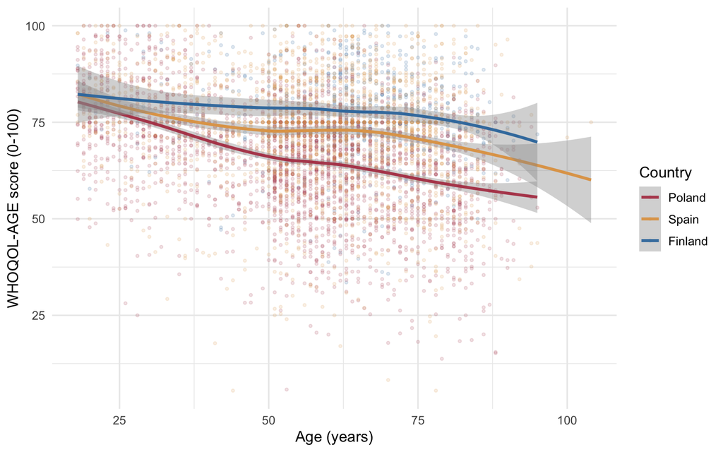

Figure 1. WHOQOL-AGE score against age, by country, with loess smooths.

## Univariable models

| **Characteristic** | **N** | **Beta** | **95% CI** | **p-value** |
| --- | --- | --- | --- | --- |
| Age (years) | 5,341 | -0.20 | -0.22, -0.18 | <0.001 |
| Sex | 5,341 |  |  |  |
| Female |  | — | — |  |
| Male |  | 2.0 | 1.2, 2.8 | <0.001 |
| Country | 5,341 |  |  |  |
| Poland |  | — | — |  |
| Spain |  | 6.6 | 5.8, 7.4 | <0.001 |
| Finland |  | 11 | 10, 13 | <0.001 |
| Education | 5,341 |  |  |  |
| None, primary or secondary |  | — | — |  |
| High school or higher |  | 6.7 | 5.9, 7.5 | <0.001 |
| Marital status | 5,341 |  |  |  |
| Married or cohabiting |  | — | — |  |
| Never married |  | 1.2 | 0.12, 2.3 | 0.030 |
| Separated or divorced |  | -4.8 | -6.2, -3.4 | <0.001 |
| Widowed |  | -7.1 | -8.2, -6.1 | <0.001 |
| BMI category | 5,341 |  |  |  |
| Normal or underweight |  | — | — |  |
| Overweight |  | -1.6 | -2.6, -0.72 | <0.001 |
| Obese |  | -4.7 | -5.7, -3.7 | <0.001 |
| Physical activity | 5,341 |  |  |  |
| High |  | — | — |  |
| Moderate |  | 0.44 | -0.49, 1.4 | 0.4 |
| Low |  | -6.6 | -7.5, -5.6 | <0.001 |
| Social network index (0-100) | 5,341 | 0.36 | 0.33, 0.39 | <0.001 |
| Home usability and safety (0-100) | 5,341 | 0.21 | 0.20, 0.23 | <0.001 |
| Bodily pain | 5,341 |  |  |  |
| None |  | — | — |  |
| Pain without difficulty |  | -0.46 | -1.5, 0.62 | 0.4 |
| Mild difficulty |  | -7.7 | -8.7, -6.8 | <0.001 |
| Moderate difficulty |  | -13 | -14, -12 | <0.001 |
| Severe or extreme difficulty |  | -21 | -22, -20 | <0.001 |
| Difficulty sleeping | 5,341 |  |  |  |
| None |  | — | — |  |
| Mild |  | -5.2 | -6.2, -4.3 | <0.001 |
| Moderate |  | -10 | -11, -9.3 | <0.001 |
| Severe or extreme |  | -16 | -17, -15 | <0.001 |
| Diagnosed arthritis | 5,341 |  |  |  |
| No |  | — | — |  |
| Yes |  | -6.1 | -6.9, -5.2 | <0.001 |
| Diagnosed angina | 5,341 |  |  |  |
| No |  | — | — |  |
| Yes |  | -9.0 | -10, -7.5 | <0.001 |
| Diagnosed diabetes | 5,341 |  |  |  |
| No |  | — | — |  |
| Yes |  | -6.5 | -7.7, -5.2 | <0.001 |
| Diagnosed depression | 5,341 |  |  |  |
| No |  | — | — |  |
| Yes |  | -8.6 | -9.7, -7.5 | <0.001 |

Abbreviation: CI = Confidence Interval

Bodily pain shows the largest crude association of any predictor: compared with participants reporting no pain, those with severe or extreme pain-related difficulty score -21.22 points (95% CI -22.44 to -20.00) lower (p <0.001), and the gradient is monotonic across the intermediate categories. Severe or extreme sleep difficulty is associated with -16.06 points (95% CI -17.28 to -14.84) (p <0.001) and a depression diagnosis with -8.58 points (95% CI -9.67 to -7.48) (p <0.001). Country is the next strongest: Finnish participants score 11.40 points (95% CI 10.18 to 12.62) higher than Polish participants (p <0.001) and Spanish participants 6.61 points (95% CI 5.81 to 7.42) higher (p <0.001). Each additional point of the social network index is associated with 0.36 points (95% CI 0.33 to 0.39) (p <0.001) and each point of home usability with 0.21 points (95% CI 0.20 to 0.23) (p <0.001), so across the full 0-100 range of those scales the implied differences are large. Each additional year of age is associated with -0.20 points (95% CI -0.22 to -0.18) (p <0.001), about 2.0 points per decade. Widowhood (-7.12 points (95% CI -8.17 to -6.08), p <0.001), low physical activity (-6.55 points (95% CI -7.49 to -5.62), p <0.001), arthritis (-6.05 points (95% CI -6.93 to -5.17), p <0.001), angina (-8.99 points (95% CI -10.44 to -7.54), p <0.001), diabetes (-6.46 points (95% CI -7.68 to -5.24), p <0.001) and obesity (-4.69 points (95% CI -5.69 to -3.70), p <0.001) all show clear crude deficits. Men score 1.97 points (95% CI 1.18 to 2.76) **higher** than women (p <0.001) - a result that does not survive adjustment.

## Why adjustment is needed

**Age** is the dominant confounder in this dataset and it operates on almost every crude estimate. Older participants are far more likely to be widowed, to report arthritis, angina and diabetes, to have bodily pain and to be in the low physical-activity category, and they independently score lower on WHOQOL-AGE. The crude -7.12 points (95% CI -8.17 to -6.08) deficit for widowhood is therefore substantially a statement about age: the median age of widowed participants is 74 against 59 for the married or cohabiting. The same argument applies to arthritis, angina and diabetes, whose crude coefficients are largely age in disguise.

**Country** is the second, and it is structural rather than incidental. Mean WHOQOL-AGE is 77.5 in Finland, 72.7 in Spain and 66.1 in Poland, and the three national samples differ sharply in education (68% of Finnish participants have high school or higher against 54% of Polish participants) and in age. Any crude education or social-network coefficient is therefore partly a between-country comparison. **Sex** works differently again: women report more bodily pain (11.4% report severe or extreme pain difficulty against 7.9% of men), so the crude male advantage is a pain difference; holding pain constant should reverse it. Mutual adjustment lets each coefficient be read as a comparison between participants alike on the other measured characteristics.

## Multivariable model

| **Characteristic** | **Beta** | **95% CI** | **p-value** |
| --- | --- | --- | --- |
| Age (years) | -0.07 | -0.09, -0.04 | <0.001 |
| Sex |  |  |  |
| Female | — | — |  |
| Male | -0.75 | -1.4, -0.11 | 0.022 |
| Country |  |  |  |
| Poland | — | — |  |
| Spain | 2.7 | 1.9, 3.4 | <0.001 |
| Finland | 9.0 | 7.9, 10 | <0.001 |
| Education |  |  |  |
| None, primary or secondary | — | — |  |
| High school or higher | 2.8 | 2.1, 3.4 | <0.001 |
| Marital status |  |  |  |
| Married or cohabiting | — | — |  |
| Never married | -0.25 | -1.2, 0.65 | 0.6 |
| Separated or divorced | -1.2 | -2.3, -0.13 | 0.029 |
| Widowed | 0.20 | -0.70, 1.1 | 0.7 |
| BMI category |  |  |  |
| Normal or underweight | — | — |  |
| Overweight | 0.09 | -0.64, 0.81 | 0.8 |
| Obese | -0.14 | -0.94, 0.66 | 0.7 |
| Physical activity |  |  |  |
| High | — | — |  |
| Moderate | -0.62 | -1.4, 0.11 | 0.10 |
| Low | -2.5 | -3.2, -1.7 | <0.001 |
| Social network index (0-100) | 0.24 | 0.21, 0.27 | <0.001 |
| Home usability and safety (0-100) | 0.12 | 0.11, 0.13 | <0.001 |
| Bodily pain |  |  |  |
| None | — | — |  |
| Pain without difficulty | -1.3 | -2.3, -0.28 | 0.012 |
| Mild difficulty | -3.8 | -4.6, -2.9 | <0.001 |
| Moderate difficulty | -6.5 | -7.4, -5.5 | <0.001 |
| Severe or extreme difficulty | -12 | -13, -10 | <0.001 |
| Difficulty sleeping |  |  |  |
| None | — | — |  |
| Mild | -2.1 | -2.9, -1.3 | <0.001 |
| Moderate | -3.8 | -4.8, -2.9 | <0.001 |
| Severe or extreme | -5.8 | -6.9, -4.6 | <0.001 |
| Diagnosed arthritis |  |  |  |
| No | — | — |  |
| Yes | -0.21 | -0.97, 0.55 | 0.6 |
| Diagnosed angina |  |  |  |
| No | — | — |  |
| Yes | -1.4 | -2.5, -0.19 | 0.022 |
| Diagnosed diabetes |  |  |  |
| No | — | — |  |
| Yes | -1.3 | -2.3, -0.34 | 0.008 |
| Diagnosed depression |  |  |  |
| No | — | — |  |
| Yes | -4.5 | -5.3, -3.6 | <0.001 |

Abbreviation: CI = Confidence Interval

**Model fit: multivariable linear model for WHOQOL-AGE score**

| Statistic | Value |
| --- | --- |
| Complete-case N | 5341 |
| Parameters (excl. intercept) | 25 |
| R-squared | 0.443 |
| Adjusted R-squared | 0.441 |
| Residual SE (points) | 10.94 |

The model explains 44.3% of the variance in the WHOQOL-AGE score (adjusted R-squared 0.441), which is high for a model of a self-reported score; the gap between the raw and adjusted values is negligible because 25 parameters on 5341 observations is a modest spend. Residual standard deviation is 10.9 points against an outcome standard deviation of 14.6.

Among participants of the same age, sex, country, education, marital status, BMI category, activity level, social network, home usability, sleep and diagnosed conditions, severe or extreme pain-related difficulty is associated with -11.53 points (95% CI -12.77 to -10.28) lower quality of life (p <0.001), and the gradient across pain categories remains monotonic. Severe or extreme sleep difficulty is associated with -5.76 points (95% CI -6.89 to -4.64) (p <0.001) and a depression diagnosis with -4.45 points (95% CI -5.35 to -3.56) (p <0.001). Being Finnish rather than Polish remains worth 8.99 points (95% CI 7.90 to 10.09) (p <0.001) - the largest single contrast in the model after severe pain, and one that no combination of individual-level characteristics in this file explains away. Each point of the social network index is worth 0.24 points (95% CI 0.21 to 0.27) (p <0.001) and each point of home usability 0.12 points (95% CI 0.11 to 0.13) (p <0.001), i.e. about 4.8 and 2.4 points respectively across a 20-point difference on those scales. Low physical activity remains associated with -2.48 points (95% CI -3.23 to -1.73) (p <0.001) and high school education or above with 2.77 points (95% CI 2.12 to 3.42) (p <0.001). Age falls to -0.07 points (95% CI -0.09 to -0.04) per year (p <0.001), about 0.7 points per decade. Arthritis (-0.21 points (95% CI -0.97 to 0.55), p = 0.584) and both BMI categories are no longer independently associated, and men now score -0.75 points (95% CI -1.39 to -0.11) **lower** than women (p = 0.022), the reverse of the crude direction. These are associations among the participants observed, not effects of intervening.

**Statistical against practical significance.** With 5341 observations this model has enough power to detect differences that would not change anyone’s decision. The sex coefficient is a good example: at -0.75 points (95% CI -1.39 to -0.11) on a 0-100 scale it is formally significant (p = 0.022) but amounts to roughly 5% of one outcome standard deviation, which is not a difference a clinician or a policymaker would act on. The same caution applies to the angina (-1.36 points (95% CI -2.53 to -0.19)) and diabetes (-1.31 points (95% CI -2.28 to -0.34)) contrasts. Contrast those with severe pain (-11.53 points (95% CI -12.77 to -10.28), close to 0.8 standard deviations) or the Finland contrast (8.99 points (95% CI 7.90 to 10.09)), which are large enough to matter substantively. Significance and importance are different questions, and at this sample size only the second is informative.

## Unadjusted versus adjusted

**Table 2. Unadjusted and adjusted estimates.**

| **Characteristic** | **Unadjusted** **N** | **Unadjusted** **Beta** | **Unadjusted** **95% CI** | **Unadjusted** **p-value** | **Adjusted** **Beta** | **Adjusted** **95% CI** | **Adjusted** **p-value** |
| --- | --- | --- | --- | --- | --- | --- | --- |
| Age (years) | 5,341 | -0.20 | -0.22, -0.18 | <0.001 | -0.07 | -0.09, -0.04 | <0.001 |
| Sex | 5,341 |  |  |  |  |  |  |
| Female |  | — | — |  | — | — |  |
| Male |  | 2.0 | 1.2, 2.8 | <0.001 | -0.75 | -1.4, -0.11 | 0.022 |
| Country | 5,341 |  |  |  |  |  |  |
| Poland |  | — | — |  | — | — |  |
| Spain |  | 6.6 | 5.8, 7.4 | <0.001 | 2.7 | 1.9, 3.4 | <0.001 |
| Finland |  | 11 | 10, 13 | <0.001 | 9.0 | 7.9, 10 | <0.001 |
| Education | 5,341 |  |  |  |  |  |  |
| None, primary or secondary |  | — | — |  | — | — |  |
| High school or higher |  | 6.7 | 5.9, 7.5 | <0.001 | 2.8 | 2.1, 3.4 | <0.001 |
| Marital status | 5,341 |  |  |  |  |  |  |
| Married or cohabiting |  | — | — |  | — | — |  |
| Never married |  | 1.2 | 0.12, 2.3 | 0.030 | -0.25 | -1.2, 0.65 | 0.6 |
| Separated or divorced |  | -4.8 | -6.2, -3.4 | <0.001 | -1.2 | -2.3, -0.13 | 0.029 |
| Widowed |  | -7.1 | -8.2, -6.1 | <0.001 | 0.20 | -0.70, 1.1 | 0.7 |
| BMI category | 5,341 |  |  |  |  |  |  |
| Normal or underweight |  | — | — |  | — | — |  |
| Overweight |  | -1.6 | -2.6, -0.72 | <0.001 | 0.09 | -0.64, 0.81 | 0.8 |
| Obese |  | -4.7 | -5.7, -3.7 | <0.001 | -0.14 | -0.94, 0.66 | 0.7 |
| Physical activity | 5,341 |  |  |  |  |  |  |
| High |  | — | — |  | — | — |  |
| Moderate |  | 0.44 | -0.49, 1.4 | 0.4 | -0.62 | -1.4, 0.11 | 0.10 |
| Low |  | -6.6 | -7.5, -5.6 | <0.001 | -2.5 | -3.2, -1.7 | <0.001 |
| Social network index (0-100) | 5,341 | 0.36 | 0.33, 0.39 | <0.001 | 0.24 | 0.21, 0.27 | <0.001 |
| Home usability and safety (0-100) | 5,341 | 0.21 | 0.20, 0.23 | <0.001 | 0.12 | 0.11, 0.13 | <0.001 |
| Bodily pain | 5,341 |  |  |  |  |  |  |
| None |  | — | — |  | — | — |  |
| Pain without difficulty |  | -0.46 | -1.5, 0.62 | 0.4 | -1.3 | -2.3, -0.28 | 0.012 |
| Mild difficulty |  | -7.7 | -8.7, -6.8 | <0.001 | -3.8 | -4.6, -2.9 | <0.001 |
| Moderate difficulty |  | -13 | -14, -12 | <0.001 | -6.5 | -7.4, -5.5 | <0.001 |
| Severe or extreme difficulty |  | -21 | -22, -20 | <0.001 | -12 | -13, -10 | <0.001 |
| Difficulty sleeping | 5,341 |  |  |  |  |  |  |
| None |  | — | — |  | — | — |  |
| Mild |  | -5.2 | -6.2, -4.3 | <0.001 | -2.1 | -2.9, -1.3 | <0.001 |
| Moderate |  | -10 | -11, -9.3 | <0.001 | -3.8 | -4.8, -2.9 | <0.001 |
| Severe or extreme |  | -16 | -17, -15 | <0.001 | -5.8 | -6.9, -4.6 | <0.001 |
| Diagnosed arthritis | 5,341 |  |  |  |  |  |  |
| No |  | — | — |  | — | — |  |
| Yes |  | -6.1 | -6.9, -5.2 | <0.001 | -0.21 | -0.97, 0.55 | 0.6 |
| Diagnosed angina | 5,341 |  |  |  |  |  |  |
| No |  | — | — |  | — | — |  |
| Yes |  | -9.0 | -10, -7.5 | <0.001 | -1.4 | -2.5, -0.19 | 0.022 |
| Diagnosed diabetes | 5,341 |  |  |  |  |  |  |
| No |  | — | — |  | — | — |  |
| Yes |  | -6.5 | -7.7, -5.2 | <0.001 | -1.3 | -2.3, -0.34 | 0.008 |
| Diagnosed depression | 5,341 |  |  |  |  |  |  |
| No |  | — | — |  | — | — |  |
| Yes |  | -8.6 | -9.7, -7.5 | <0.001 | -4.5 | -5.3, -3.6 | <0.001 |

Abbreviation: CI = Confidence Interval

Several estimates move a long way. **Arthritis** collapses from -6.05 points (95% CI -6.93 to -5.17) crude to -0.21 points (95% CI -0.97 to 0.55) adjusted (p <0.001 to p = 0.584), i.e. essentially all the way to the null and out of significance: the crude arthritis deficit was age and bodily pain, and once pain is in the model arthritis has nothing left to explain. **Widowhood** does the same thing and then some, from -7.12 points (95% CI -8.17 to -6.08) crude to 0.20 points (95% CI -0.70 to 1.10) adjusted - the sign reverses and the estimate becomes non-significant, which is age confounding almost in its pure form. **Obesity** moves from -4.69 points (95% CI -5.69 to -3.70) (p <0.001) to -0.14 points (95% CI -0.94 to 0.66) (p = 0.733), again explained by pain and comorbidity. **Sex** is the most striking: 1.97 points (95% CI 1.18 to 2.76) crude, significant in the direction of men doing better, becomes -0.75 points (95% CI -1.39 to -0.11) adjusted, significant in the direction of men doing worse. This is masking rather than confounding in the usual sense - women’s higher pain burden was hiding a small female advantage - and it is a good illustration of why a crude sex difference in a symptom-laden score should not be reported on its own.

## Diagnostics

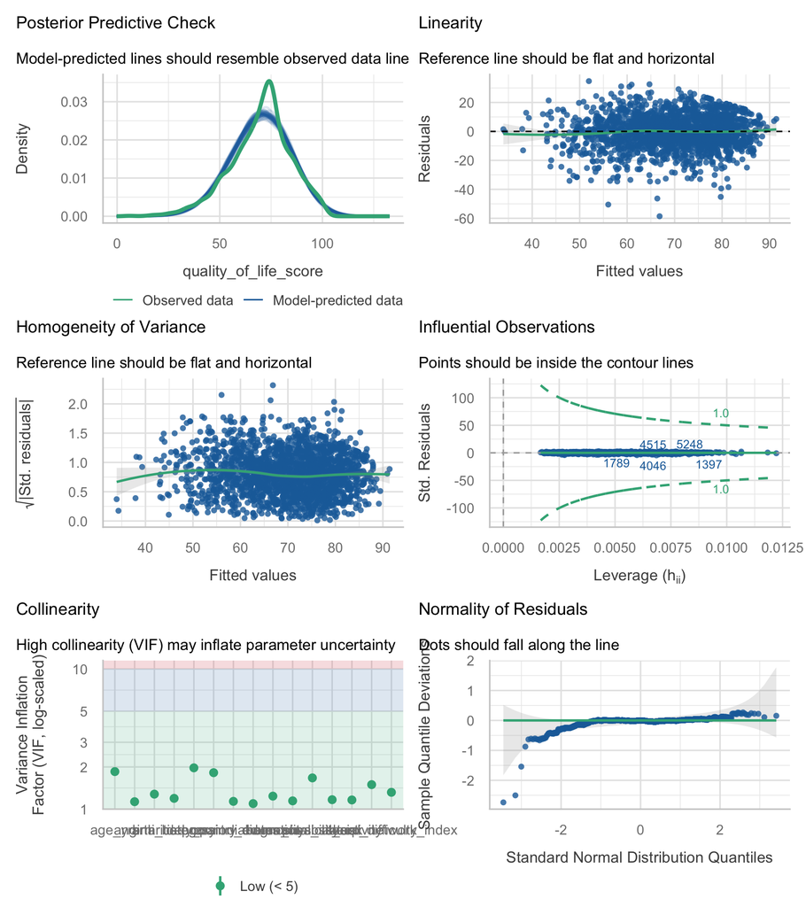

| Term | VIF | VIF_CI_low | VIF_CI_high | SE_factor | Tolerance | Tolerance_CI_low | Tolerance_CI_high |
| --- | --- | --- | --- | --- | --- | --- | --- |
| age_yrs | 1.853497 | 1.784257 | 1.928850 | 1.361432 | 0.5395208 | 0.5184436 | 0.5604575 |
| sex | 1.162922 | 1.131129 | 1.202422 | 1.078388 | 0.8599032 | 0.8316550 | 0.8840721 |
| country | 1.821026 | 1.753488 | 1.894618 | 1.161660 | 0.5491410 | 0.5278110 | 0.5702920 |
| education | 1.238396 | 1.202084 | 1.281232 | 1.112832 | 0.8074964 | 0.7804989 | 0.8318885 |
| marital_status | 1.670725 | 1.611085 | 1.736185 | 1.089308 | 0.5985427 | 0.5759756 | 0.6206997 |
| bmi_category | 1.193796 | 1.160101 | 1.234582 | 1.045280 | 0.8376642 | 0.8099910 | 0.8619938 |
| physical_activity | 1.167771 | 1.135673 | 1.207463 | 1.039536 | 0.8563323 | 0.8281830 | 0.8805350 |
| social_network_index | 1.318370 | 1.277571 | 1.365167 | 1.148203 | 0.7585123 | 0.7325112 | 0.7827355 |
| home_usability | 1.145718 | 1.115038 | 1.184581 | 1.070382 | 0.8728148 | 0.8441802 | 0.8968304 |
| body_pain | 1.970987 | 1.895596 | 2.052725 | 1.088518 | 0.5073599 | 0.4871573 | 0.5275385 |

[output cut: 5 more lines]

**Table 3. HC3 heteroscedasticity-consistent standard errors.**

| Term | Estimate | SE (OLS) | SE (HC3) | 95% CI (HC3) | p (HC3) |
| --- | --- | --- | --- | --- | --- |
| age_yrs | -0.066 | 0.012 | 0.012 | -0.09 to -0.04 | 0.000 |
| sexMale | -0.748 | 0.327 | 0.327 | -1.39 to -0.11 | 0.022 |
| countrySpain | 2.674 | 0.376 | 0.386 | 1.92 to 3.43 | 0.000 |
| countryFinland | 8.993 | 0.558 | 0.502 | 8.01 to 9.98 | 0.000 |
| educationHigh school or higher | 2.770 | 0.333 | 0.328 | 2.13 to 3.41 | 0.000 |
| marital_statusNever married | -0.253 | 0.462 | 0.482 | -1.20 to 0.69 | 0.600 |
| marital_statusSeparated or divorced | -1.227 | 0.560 | 0.589 | -2.38 to -0.07 | 0.037 |
| marital_statusWidowed | 0.198 | 0.461 | 0.472 | -0.73 to 1.12 | 0.674 |
| bmi_categoryOverweight | 0.086 | 0.369 | 0.369 | -0.64 to 0.81 | 0.817 |
| bmi_categoryObese | -0.140 | 0.410 | 0.413 | -0.95 to 0.67 | 0.734 |
| physical_activityModerate | -0.623 | 0.374 | 0.365 | -1.34 to 0.09 | 0.088 |
| physical_activityLow | -2.478 | 0.381 | 0.390 | -3.24 to -1.71 | 0.000 |
| social_network_index | 0.240 | 0.013 | 0.015 | 0.21 to 0.27 | 0.000 |
| home_usability | 0.121 | 0.007 | 0.008 | 0.11 to 0.14 | 0.000 |
| body_painPain without difficulty | -1.272 | 0.505 | 0.488 | -2.23 to -0.31 | 0.009 |
| body_painMild difficulty | -3.750 | 0.440 | 0.432 | -4.60 to -2.90 | 0.000 |
| body_painModerate difficulty | -6.491 | 0.487 | 0.482 | -7.44 to -5.55 | 0.000 |
| body_painSevere or extreme difficulty | -11.528 | 0.635 | 0.750 | -13.00 to -10.06 | 0.000 |
| sleep_difficultyMild | -2.112 | 0.418 | 0.416 | -2.93 to -1.30 | 0.000 |
| sleep_difficultyModerate | -3.847 | 0.465 | 0.467 | -4.76 to -2.93 | 0.000 |
| sleep_difficultySevere or extreme | -5.762 | 0.574 | 0.614 | -6.97 to -4.56 | 0.000 |
| arthritisYes | -0.212 | 0.388 | 0.404 | -1.00 to 0.58 | 0.599 |
| anginaYes | -1.363 | 0.597 | 0.609 | -2.56 to -0.17 | 0.025 |
| diabetesYes | -1.312 | 0.493 | 0.516 | -2.32 to -0.30 | 0.011 |
| depression_diagnosisYes | -4.454 | 0.455 | 0.495 | -5.42 to -3.48 | 0.000 |

The linearity and posterior-predictive panels are acceptable but not clean. The observed outcome has a ceiling - 59 participants score exactly 100 and 355 score exactly 75, a scoring artefact of the instrument - and the fitted normal predictive distribution cannot reproduce either feature. The residual-versus-fitted panel shows the spread narrowing at high fitted values, which is what a ceiling produces, and `check_heteroscedasticity()` rejects constant variance (p < 0.001). Residuals are left-skewed (skewness -0.37, milder than the raw outcome’s -0.52) and `check_normality()` also rejects; with 5341 observations both tests would reject trivial departures, so the QQ plot matters more than the p-value, and it shows a heavy lower tail rather than a wholesale failure. Collinearity is not a problem: the largest VIF is 1.97 for body_pain, well below the conventional threshold of 5, and the pain, sleep and depression terms are not competing as badly as their substantive overlap would suggest. Influence is negligible: the largest Cook’s distance is 0.0087 and the largest leverage 0.012, so no participant drives the fit.

Table 3 reports HC3 robust standard errors because variance is non-constant. They change very little - the largest ratio of HC3 to OLS standard error is 1.18 - and **0** coefficients change significance status under robust inference, so the substantive conclusions stand. A transformation would help the skew (squaring the score reduces residual skewness to about 0.21) but at the cost of coefficients that no longer read in points of WHOQOL-AGE, and it does not change which predictors matter; we therefore report the untransformed model and flag the violation.

**Table 4. Sensitivity analysis: dropping the symptom and diagnosis predictors.**

[output not shown]

Table 4 is the analysis that decides how much of this model to believe. Dropping `body_pain`, `sleep_difficulty` and `depression_diagnosis` takes R-squared from 0.443 to 0.341, so those three predictors alone account for 10.2 percentage points of explained variance, roughly 23% of everything the model explains. Without them, age recovers to -0.11 points (95% CI -0.14 to -0.09) per year, obesity becomes -1.00 points (95% CI -1.87 to -0.13) and significant again, sex reverts to men scoring 0.80 points (95% CI 0.12 to 1.49) higher, and the Finland contrast grows to 11.88 points (95% CI 10.79 to 12.98). Every one of those changes is what you would expect if the symptom variables sit *between* the demographic predictors and the outcome, or are part of the outcome itself.

# Discussion

**The reflection problem is the main interpretive weakness of this analysis.** WHOQOL-AGE is a summary of how people rate their own physical health, psychological state, social relationships and environment. `body_pain`, `sleep_difficulty` and `sadness` are not distant causes of that rating - they are close to being the things the rating is made of. Asking someone how much pain interferes with their life and then asking them to rate their quality of life is asking two versions of the same question, and regressing the second on the first recovers the arithmetic of the instrument as much as any causal relationship. The same argument, more weakly, applies to `social_network_index` and `home_usability`, which measure the social-relationships and environment domains that WHOQOL-AGE itself contains. Table 4 quantifies the problem: the three symptom-and-diagnosis predictors carry 10.2 percentage points of R-squared on their own, and removing them changes the direction of the sex coefficient and restores significance to obesity. Even where the relationship is genuinely causal rather than definitional, the direction is unclear in a cross-sectional survey: poor quality of life plausibly worsens sleep and amplifies reported pain as much as the reverse. The honest reading is that the pain, sleep and depression coefficients describe how the components of a quality-of-life score hang together, and that the demographic and structural coefficients (age, sex, country, education, obesity) are the ones with a defensible causal interpretation - and those should be read from the sensitivity model in Table 4, not from the full model, because the full model conditions on variables that sit on the pathway.

**Limitations.** The models are **unweighted**: the COURAGE sampling weights, strata and clusters are not carried in this file, so the sample must not be described as representative of any national population and the standard errors ignore clustering within primary sampling units, which will make them too small. The design is cross-sectional, so temporality is unknown and reverse causation is live for every symptom predictor, as set out above; adjusting for pain, sleep and depression is probably over-adjustment for mediators rather than confounder control. The deposited file differs from the published paper: it holds 5341 rows with mean age 57.8 years, whereas the source paper reports 5,639 participants with mean age 46.3 years, so this is not the analytic sample the authors modelled and results here should not be compared with theirs. Residual variance is non-constant and residuals are left-skewed because the outcome has a ceiling at 100 and a large spike at 75; HC3 standard errors address inference (changing 0 conclusions) but not the model’s inability to represent the top of the distribution. There is evidence of effect modification by country that the additive model ignores: a country-by-age interaction improves the fit (p <0.001) and a country-by-education interaction does too (p = 0.005), so the single age slope reported here is an average across three quite different national gradients. Age enters linearly although a quadratic term is significant (p <0.001). The education variable was collapsed to two levels, so any effect confined to the 125 participants with no formal education is invisible. Six suggested predictors were excluded a priori, so residual confounding by smoking, alcohol, vision and neighbourhood environment is certain. With 5341 observations, small and practically uninteresting differences reach significance. All estimates are associations, not causal effects.

**Future work.** Refit with the COURAGE survey design (weights, strata and clusters), with country-specific age slopes, and with the WHOQOL-AGE domains separated from their putative determinants so that pain and sleep are not simultaneously predictors and constituents of the outcome.

# Feasibility notes

*NOT part of a student report.*

- **USABLE, and the strongest of the three outcomes in this dataset.** No missing data at all (5341/5341 rows complete on every column), n = 5341, R-squared 0.443, no separation risk, no influential points (max Cook’s 0.0087), max VIF 1.97.
- **MAJOR: the reflection problem.** `body_pain`, `sleep_difficulty` and `sadness` are components or near-components of the WHOQOL-AGE construct, and `social_network_index` and `home_usability` overlap with its social and environment domains. Dropping the first three takes R-squared from 0.443 to 0.341. A student who includes them and writes “pain reduces quality of life” has stated something close to a tautology. This is the single most important thing to warn about for this dataset, and it should probably be flagged on the dataset page.
- **MAJOR: 21 suggested predictors cost 39 parameters, not 21.** Most are multi-level factors. For the linear outcome the parameter budget is not violated (137 observations per parameter), so a student *can* fit all 21 without any warning appearing - which is exactly the trap. The result is an unreadable table in which roughly 2.0 coefficients are significant by chance. The brief must tell students to count parameters and cut.
- **MAJOR: the file does not match the paper.** 5341 rows, mean age 57.8 years, median 60, range 18-104; the paper reports 5,639 participants with mean age 46.3. Verified directly from the CSV. The age discrepancy of ~11.5 years is far too large to be a rounding or subsetting artefact and suggests the deposited S1 file is a different (older) subsample from the one analysed. Students must not be asked to reproduce published numbers, and the dataset page should carry an explicit caution.
- **MAJOR: failed diagnostics.** Heteroscedasticity p < 0.001 and non-normality p < 0.001, both driven by the ceiling: 59 participants score exactly 100 and 355 score exactly 75 (a single scoring value accounting for 6.6% of the sample). HC3 changes 0 conclusions, so this is a reportable violation rather than a threat to the findings.
- **MINOR but structural: `education == "none_or_informal"` is a Spain-only category.** 124 of its 125 members are Spanish and **zero** are Finnish. Kept as three levels alongside `country` it is estimable but the contrast is a within-Spain contrast; interacted with `country` it produces outright separation. Collapsed to two levels here.
- **MINOR: `alcohol_use` has a `frequent_heavy` level of 35 participants** (9 with depression, 11 with hypertension). Harmless in a linear model, dangerous in the logistic ones - see the other two documents.
- **MINOR: unmodelled effect modification by country.** country-by-age p <0.001, country-by-education p = 0.005. The additive model is a simplification, not a description of three parallel populations. A good student can mention it; the workshop does not require interactions.
- **MINOR: non-linear age.** A quadratic age term is significant (p <0.001), so the linear age coefficient understates the decline at the oldest ages.
- **Unweighted survey analysis.** Must be stated in Methods and Limitations for every outcome in this dataset.